3. Relationship target Variable

as you know if the quality is low so the price is, and vice versa, oke than lets see whats the visual show us The corresponding variable is OverallQual which values consist of :

```
10 = Very Excellent
9 = Excellent
8 = Very Good
7 = Good
6= = Average
5 = Average
4 = Below Average
3 = Fair
2 = Poor
1 = Very Poor
```

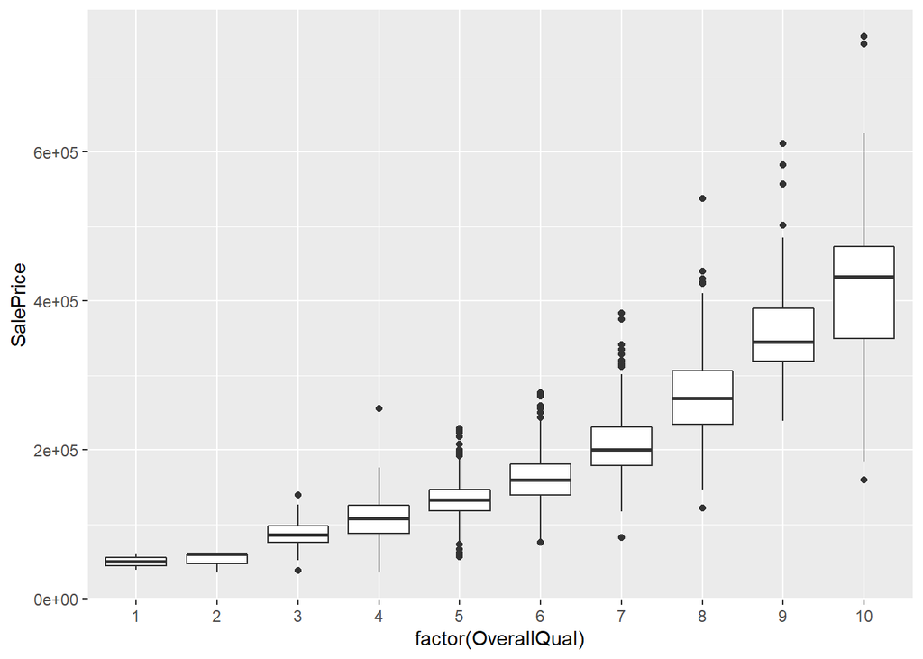

```r
df %>%
ggplot(aes(x=factor(OverallQual),y=SalePrice)) + geom_boxplot()
```

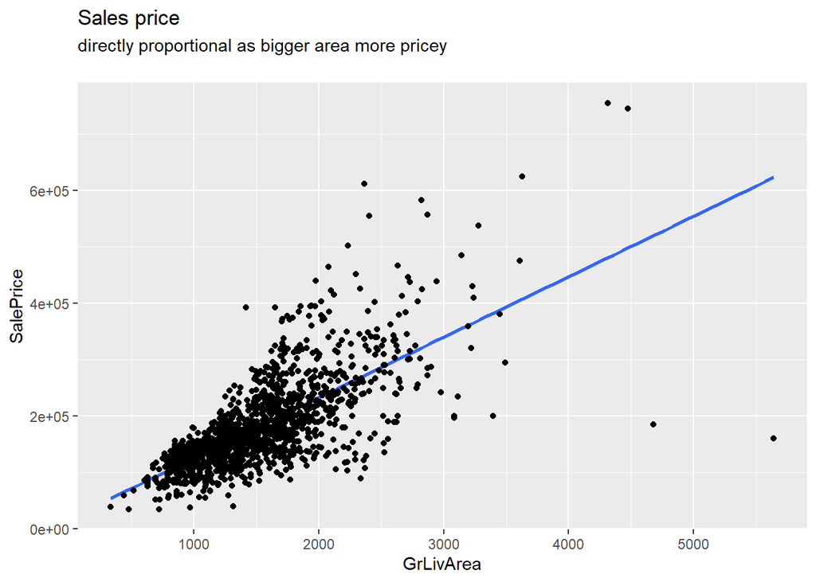

```r
df %>%
  ggplot(aes(x = GrLivArea, y = SalePrice)) +
  geom_smooth(method='lm', se=FALSE)+
  labs(title = 'Sales price', subtitle = 'directly proportional as bigger area more pricey \n')+
  geom_point()
```

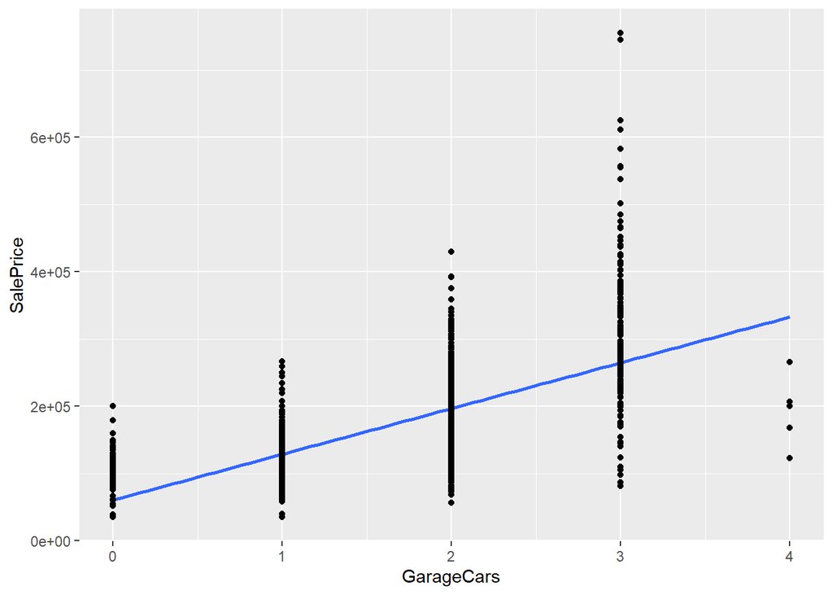

```r
df %>%
  ggplot(aes(x = GarageCars, y = SalePrice)) +
  geom_smooth(method='lm', se=FALSE)+
  geom_point()
```

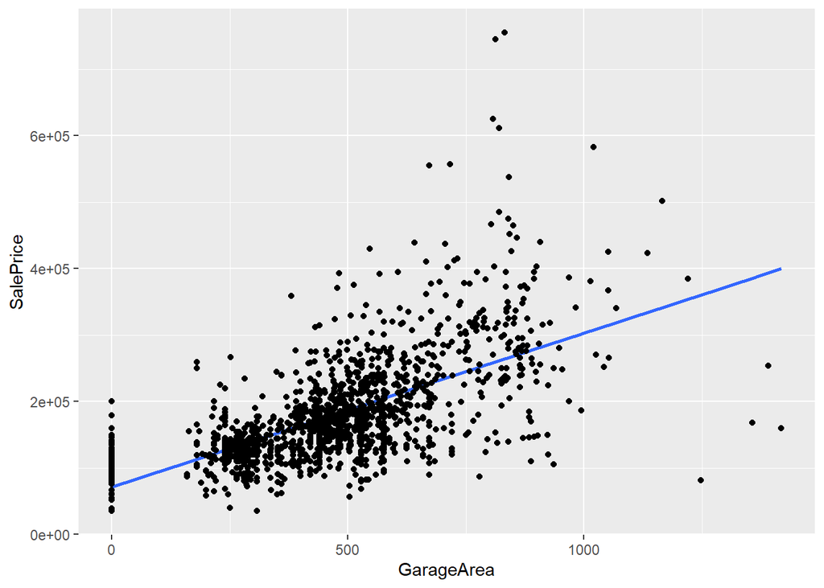

```r
df %>%
  ggplot(aes(x = GarageArea, y = SalePrice)) +
  geom_smooth(method='lm', se=FALSE)+
  geom_point()
```

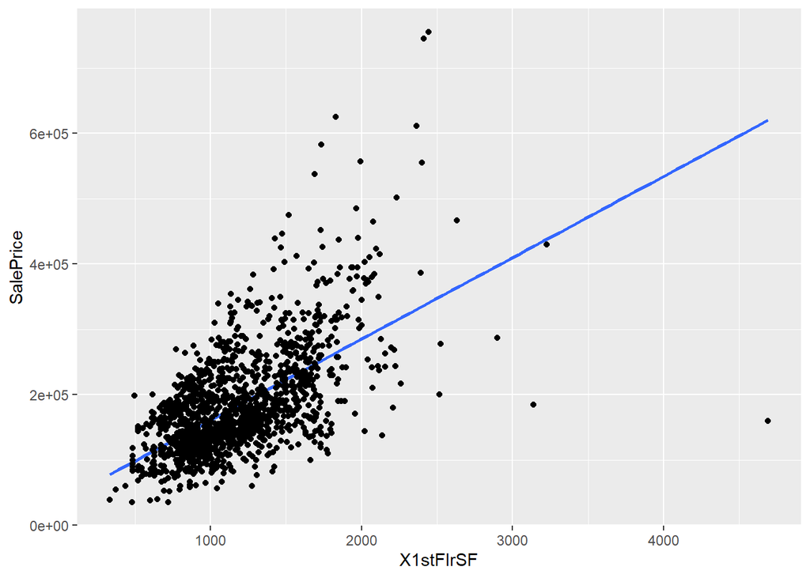

```r
df %>%
  ggplot(aes(x = X1stFlrSF, y = SalePrice)) +
  geom_smooth(method='lm', se=FALSE)+
  geom_point()
```

According to the heatmap there are the graph SalePrice with several strong correlation

```
1. bassicly the graph say the truth the higher the quality, more pricey it is
2. in this graph GrlivArea there 2 anomalies/outlier. with the house area more than 4k square feet but it sales under 200k , what        happend? is there any particular reason the owner sell it under the market ?
3. For the GarageCars and GarageArea its just the same like a twin.
4. and 1stFlrSF slightly same with the GrlivArea
```

4. Feature Engineering

```r
  df2 = df %>%
  mutate(age_after_remodAdd = 2021 - YearRemodAdd,
         age_built_to_remodAdd = YearRemodAdd - YearBuilt,
         age_sell = YrSold - YearBuilt,
         age_sell_to_month = age_sell * 12,
         OQ_redefine = case_when(OverallQual <= 4 ~ "low",
                        OverallQual > 4 & OverallQual < 8  ~ "medium",
                        OverallQual >= 8 ~ "high"),
         MS_redefine = case_when(MoSold <= 6 ~ "Awal Tahun",
                        MoSold > 6 ~ "Akhir Tahun"),
         HouseType = case_when(YearBuilt >= 1800 & YearBuilt <= 1950 ~ "Antique",
                     YearBuilt >= 1951 & YearBuilt <= 2007 ~ "Recent",
                     YearBuilt > 2008 ~ "Modern"),
         quartal = case_when(MoSold <= 3 ~ "Quartal 1",
                        MoSold > 3 & MoSold <= 6  ~ "Quartal 2",
                        MoSold > 6 & MoSold <= 9  ~ "Quartal 3",
                        MoSold > 9 ~ "Quartal 4"))
```

```r
df2 %>%
  select(Id, age_after_remodAdd, age_built_to_remodAdd, age_sell, age_sell_to_month, OQ_redefine, MS_redefine, HouseType, quartal)
```

```
##        Id age_after_remodAdd age_built_to_remodAdd age_sell age_sell_to_month
## 1       1                 18                     0        5                60
## 2       2                 45                     0       31               372
## 3       3                 19                     1        7                84
## 4       4                 51                    55       91              1092
## 5       5                 21                     0        8                96
## 6       6                 26                     2       16               192
## 7       7                 16                     1        3                36
## 8       8                 48                     0       36               432
## 9       9                 71                    19       77               924
## 10     10                 71                    11       69               828
## 11     11                 56                     0       43               516
## 12     12                 15                     1        1                12
## 13     13                 59                     0       46               552
## 14     14                 14                     1        1                12
```

[output cut: 2907 more lines]

```r
  head(df2)
```

```
##   Id MSSubClass MSZoning LotFrontage LotArea Street Alley LotShape LandContour
## 1  1         60       RL          65    8450   Pave  <NA>      Reg         Lvl
## 2  2         20       RL          80    9600   Pave  <NA>      Reg         Lvl
## 3  3         60       RL          68   11250   Pave  <NA>      IR1         Lvl
## 4  4         70       RL          60    9550   Pave  <NA>      IR1         Lvl
## 5  5         60       RL          84   14260   Pave  <NA>      IR1         Lvl
## 6  6         50       RL          85   14115   Pave  <NA>      IR1         Lvl
##   Utilities LotConfig LandSlope Neighborhood Condition1 Condition2 BldgType
## 1    AllPub    Inside       Gtl      CollgCr       Norm       Norm     1Fam
## 2    AllPub       FR2       Gtl      Veenker      Feedr       Norm     1Fam
## 3    AllPub    Inside       Gtl      CollgCr       Norm       Norm     1Fam
## 4    AllPub    Corner       Gtl      Crawfor       Norm       Norm     1Fam
## 5    AllPub       FR2       Gtl      NoRidge       Norm       Norm     1Fam
## 6    AllPub    Inside       Gtl      Mitchel       Norm       Norm     1Fam
##   HouseStyle OverallQual OverallCond YearBuilt YearRemodAdd RoofStyle RoofMatl
```

[output cut: 83 more lines]